# Preprosesamiento

# Adquiriendo los datos

```r
data_raw_1 <- read_csv("Data/Networking como una herramienta del Modelo Efectual.csv")
dim(data_raw_1)
```

```
[1] 300  38
```

# Limpiando los datos

Organizamos los nombres de las columnas por la variables que estamos midiendo y le añadimos QX.

```r
nombres_columnas <- c("dia",
                      "email", "nombre", "sector", "genero", "edad", "escolaridad",
                      "ME_Q1", "ME_Q2", "ME_Q3", "ME_Q4",
                      "RED_Q1",
                      "RED_Q2_C1", "RED_Q2_C2","RED_Q2_C3", "RED_Q2_C4", "RED_Q2_C5",
                      "RED_Q3_C1", "RED_Q3_C2","RED_Q3_C3", "RED_Q3_C4", "RED_Q3_C5",
                      "NET_Q1", "NET_Q2", "NET_Q3", "NET_Q4",
                      "WOM_Q1", "WOM_Q2", "WOM_Q3",
                      "PER_Q1", "PER_Q2", "PER_Q3", "PER_Q4", "PER_Q5",
                      "DESEM_Q1", "DESEM_Q2", "DESEM_Q3", "DESEM_Q4")
```

Actualizamos los nombres de las columnas

```r
names(data_raw_1) <- nombres_columnas
```

Primero eliminamos los 4 registros del inicio que fueron pruebas pilotos. Después liminamos las columnas dia, nombre y nombres de clientes. También pasamos todos los correos a letra minúscula. Después se pueden cruzar con los datos de cámara y comercio.

```r
data_raw_2 <- data_raw_1[-c(1:4), -c(1,3,12)]
data_raw_2$email <- tolower(data_raw_2$email)
dim(data_raw_2)
```

```
[1] 296  35
```

Se encontraron correos electrónicos repetidos con diferente información. Estos se dejan pero es necesario revisar qué fue lo que pasó. Esto es debido a que un emprendedor puede tener varias empresas.

```r
duplicados <- data_raw_2[data_raw_2$email %in% c("tatianavilla29@outlook.es",
                                                 "leidy.aleja124@gmail.com",
                                                 "alejandroramirez@arquitecto.com"),
                         1:4]
duplicados[order(duplicados$email),]
```

| email | sector | genero | edad |
| --- | --- | --- | --- |
| alejandroramirez@arquitecto.com | Industria | Hombre | 44 |
| alejandroramirez@arquitecto.com | Comercio | Mujer | 36 |
| leidy.aleja124@gmail.com | Servicios | Hombre | 50 |
| leidy.aleja124@gmail.com | Comercio | Hombre | 39 |
| tatianavilla29@outlook.es | Comercio | Mujer | 24 |
| tatianavilla29@outlook.es | Comercio | Mujer | 45 |

Les añadimos un 1 al final(295, 17, 267)

```r
data_raw_2$email[295] <- "alejandroramirez@arquitecto.com_1"
data_raw_2$email[17] <- "leidy.aleja124@gmail.com_1"
data_raw_2$email[267] <- "tatianavilla29@outlook.es_1"
```

Revisamos la cantidad de NA’s que hay por columna. Excluimos las variables de control ya que todas están completas en este momento. También excluimos las preguntas acerca de la egonetwork debido a que por su naturaleza debe haber NA’s.

Ahora unimos los datos

El resultado final es un dataset de 288 registros con 35 variables.

### Variables de control: Limpieza

Se convierten las variables sector, genero y escolaridad en variables categóricas.

```r
data_raw_3$sector <- factor(data_raw_3$sector)
data_raw_3$genero <- factor(data_raw_3$genero)
data_raw_3$escolaridad  <- factor(data_raw_3$escolaridad)
```

Edad es una variable continua, se transforma a entera

```r
data_raw_3$edad <- as.integer(data_raw_3$edad)
str(data_raw_3[,c("sector", "genero", "escolaridad", "edad")])
```

```
Classes 'tbl_df', 'tbl' and 'data.frame':   288 obs. of  4 variables:
 $ sector     : Factor w/ 3 levels "Comercio","Industria",..: 3 3 1 3 3 3 3 1 1 1 ...
 $ genero     : Factor w/ 2 levels "Hombre","Mujer": 2 2 1 1 1 2 2 2 1 1 ...
 $ escolaridad: Factor w/ 3 levels "Posgrado","Pregrado",..: 2 3 3 1 3 3 2 2 2 2 ...
 $ edad       : int  30 29 56 37 64 62 26 51 27 37 ...
```

### Modelo Efectual: limpieza

#### Validez de los constructos

Este procedimiento es igual para las variables categóricas que se pasan a enteras.

```r
cor(data_raw_3[,c("ME_Q1", "ME_Q2", "ME_Q3", "ME_Q4")], use = "complete")
```

```
           ME_Q1     ME_Q2      ME_Q3      ME_Q4
ME_Q1 1.00000000 0.1686784 0.02285201 0.04292137
ME_Q2 0.16867835 1.0000000 0.36628838 0.44549911
ME_Q3 0.02285201 0.3662884 1.00000000 0.44854327
ME_Q4 0.04292137 0.4454991 0.44854327 1.00000000
```

La pregunta 1 tiene una correlación por debajo de 0.4 con las otras variables, por lo tanto se elimina del constructo.

Ahora se procede a realizar la normalización de los items (Levin and Cross (MS2001)) y crear la variable final del Modelo efectual.

```r
data_raw_3 <- local({
  .Z <- scale(data_raw_3[,c("ME_Q2", "ME_Q3", "ME_Q4")])
  within(data_raw_3, {
    ME_Q4 <- .Z[,3]
    ME_Q3 <- .Z[,2]
    ME_Q2 <- .Z[,1]

  })
})
```

Con los datos normalizados, hallamos el Cronbach Alpha

```r
RcmdrMisc::reliability(cov(data_raw_3[,c("ME_Q2", "ME_Q3", "ME_Q4")], use ="complete.obs"))
```

```
Alpha reliability =  0.6849
Standardized alpha =  0.6849

Reliability deleting each item in turn:
       Alpha Std.Alpha r(item, total)
ME_Q2 0.6193    0.6193         0.4769
ME_Q3 0.6164    0.6164         0.4792
ME_Q4 0.5362    0.5362         0.5408
```

Es encesario revisar esta variable ya que el cronbach alpha está cercano a 0.70

Es necesario realizar más validaciónes para confirmar el constructo.

Finalmente, creamos el valor para la variable del modelo efectual

```r
data_raw_3$modelo_efectual <- apply(data_raw_3[,c("ME_Q2", "ME_Q3", "ME_Q4")], 1, mean)
summary(data_raw_3$modelo_efectual)
```

```
   Min. 1st Qu.  Median    Mean 3rd Qu.    Max.
-3.1002 -0.5707  0.2695  0.0000  0.7537  0.7537
```

Graficamos el histograma de la variable modelo efectual

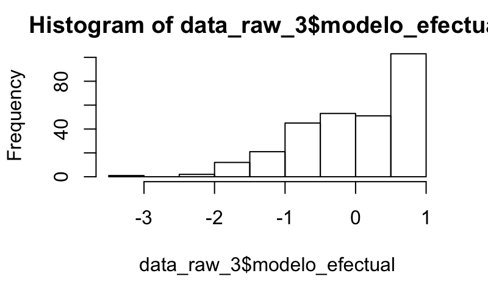

```r
hist(data_raw_3$modelo_efectual)
```

### Estructura de la red

Para la primera pregunta acerca de la ego-network, creamos las conexiones entre los clientes y hallamos los indicadores de constraint e intermediación.

```r
df_egonet <- data.frame(email = character(),
                        constraint = numeric(),
                        betweenness = numeric(),
                        stringsAsFactors = FALSE)

for (i in data_raw_3$email) {

        row = data_raw_3[data_raw_3$email == i, c("email",
                                                  "RED_Q2_C1",
                                                  "RED_Q2_C2",
                                                  "RED_Q2_C3",
                                                  "RED_Q2_C4",
                                                  "RED_Q2_C5")]
        df_entre = data.frame(Source = i,
                              Target = c("Cliente 1",
                                         "Cliente 2",
                                         "Cliente 3",
                                         "Cliente 4",
                                         "Cliente 5"))

        df_c1 = data.frame(Source = "Cliente 1",
                           Target = strsplit(x = row$RED_Q2_C1, split = ";"),
                           stringsAsFactors = FALSE)
        names(df_c1) = c("Source", "Target")

        df_c2 = data.frame(Source = "Cliente 2",
                           Target = strsplit(x = row$RED_Q2_C2, split = ";"),
                           stringsAsFactors = FALSE)
        names(df_c2) = c("Source", "Target")

        df_c3 = data.frame(Source = "Cliente 3",
                           Target = strsplit(x = row$RED_Q2_C3, split = ";"),
                           stringsAsFactors = FALSE)
        names(df_c3) = c("Source", "Target")

        df_c4 = data.frame(Source = "Cliente 4",
                           Target = strsplit(x = row$RED_Q2_C4, split = ";"),
                           stringsAsFactors = FALSE)
        names(df_c4) = c("Source", "Target")

        df_c5 = data.frame(Source = "Cliente 5",
                           Target = strsplit(x = row$RED_Q2_C5, split = ";"),
                           stringsAsFactors = FALSE)
        names(df_c5) = c("Source", "Target")

        edge_list = rbind(df_entre, df_c1, df_c2, df_c3, df_c4, df_c5)

        edge_list = edge_list[complete.cases(edge_list) == TRUE,]

        graph_1 = graph.data.frame(edge_list, directed = FALSE)

        net_metrics = data.frame(email = i,
                                 constraint = constraint(graph_1)[1],
                                 betweenness = betweenness(graph_1,
                                                           normalized = TRUE)[1],
                                 stringsAsFactors = FALSE)

        df_egonet = rbind(net_metrics, df_egonet)
}

rm(row, df_c1, df_c2, df_c3, df_c4, df_c5, df_entre)
```

```r
hist(df_egonet$constraint)
```

[output not shown]

Se transforman los datos para que se acerque a una distribución normal

```r
hist(df_egonet$betweenness)
```

[output not shown]

Se transforman los datos para que se acerquen a una distribución normal

```r
df_egonet$betweenness <- autoTransform(df_egonet$betweenness)
hist(df_egonet$betweenness)
```

[output not shown]

### Fortaleza del enlace

No estoy seguro la fuente de estas preguntas. Sería bueno revisar para determinar como construimos el indicador.

### Actividades de networking: limpieza y organización.

Para construir este indicador se utilizaron 4 preguntas. Cada una con una escala likert de 1 a 5. Donde 1 es muy bajo y 5 muy alto.

```r
cor(data_raw_3[,c("NET_Q1", "NET_Q2", "NET_Q3", "NET_Q4")], use = "complete")
```

```
          NET_Q1    NET_Q2    NET_Q3    NET_Q4
NET_Q1 1.0000000 0.6030200 0.3397162 0.4631932
NET_Q2 0.6030200 1.0000000 0.3914977 0.5234626
NET_Q3 0.3397162 0.3914977 1.0000000 0.3503765
NET_Q4 0.4631932 0.5234626 0.3503765 1.0000000
```

Ahora se procede a realizar la normalización de los items (Levin and Cross (MS2001)) y crear la variable final de networking.

Con los datos normalizados, hallamos el Cronbach Alpha

```r
RcmdrMisc::reliability(cov(data_raw_3[,c("NET_Q1", "NET_Q2", "NET_Q3", "NET_Q4")], use ="complete.obs"))
```

[output not shown]

Finalmente, creamos el valor para la variable networking

Graficamos el histograma de la variable networking

```r
hist(data_raw_3$networking)
```

[output not shown]

### WOM

Hacemos el mismo proceso que en las anteriores.

```r
cor(data_raw_3[,c("WOM_Q1", "WOM_Q2", "WOM_Q3")], use = "complete")
```

```
          WOM_Q1    WOM_Q2    WOM_Q3
WOM_Q1 1.0000000 0.6128003 0.5933392
WOM_Q2 0.6128003 1.0000000 0.6821848
WOM_Q3 0.5933392 0.6821848 1.0000000
```

Ahora se procede a realizar la normalización de los items (Levin and Cross (MS2001)) y crear la variable final de networking.

Con los datos normalizados, hallamos el Cronbach Alpha

```r
RcmdrMisc::reliability(cov(data_raw_3[,c("WOM_Q1", "WOM_Q2", "WOM_Q3")], use ="complete.obs"))
```

[output not shown]

Finalmente, creamos el valor para la variable WOM

Graficamos el histograma de la variable WOM

```r
hist(data_raw_3$WOM)
```

[output not shown]

### Personalidad Emprendedora

Hacemos el mismo proceso

```r
cor(data_raw_3[,c("PER_Q1", "PER_Q2", "PER_Q3", "PER_Q4", "PER_Q5")], use = "complete")
```

```
          PER_Q1    PER_Q2    PER_Q3    PER_Q4    PER_Q5
PER_Q1 1.0000000 0.5236621 1.0000000 0.5236621 0.1768424
PER_Q2 0.5236621 1.0000000 0.5236621 1.0000000 0.2782790
PER_Q3 1.0000000 0.5236621 1.0000000 0.5236621 0.1768424
PER_Q4 0.5236621 1.0000000 0.5236621 1.0000000 0.2782790
PER_Q5 0.1768424 0.2782790 0.1768424 0.2782790 1.0000000
```

Ahora se procede a realizar la normalización de los items (Levin and Cross (MS2001)) y crear la variable final de personalidad emprendedora

Con los datos normalizados, hallamos el Cronbach Alpha

```r
RcmdrMisc::reliability(cov(data_raw_3[,c("PER_Q1", "PER_Q2", "PER_Q3", "PER_Q4", "PER_Q5")], use ="complete.obs"))
```

[output not shown]

Finalmente, creamos el valor para la variable personalidad emprendedora

Graficamos el histograma de la variable personalidad emprendedora

```r
hist(data_raw_3$personalidad_emprendedora)
```

[output not shown]

### Desempeño

El mismo proceso que en los anteriores.

```r
cor(data_raw_3[,c("DESEM_Q1", "DESEM_Q2", "DESEM_Q3", "DESEM_Q4")], use = "complete")
```

```
          DESEM_Q1  DESEM_Q2  DESEM_Q3  DESEM_Q4
DESEM_Q1 1.0000000 0.7664078 0.4159282 0.6064443
DESEM_Q2 0.7664078 1.0000000 0.4606517 0.4992925
DESEM_Q3 0.4159282 0.4606517 1.0000000 0.2868857
DESEM_Q4 0.6064443 0.4992925 0.2868857 1.0000000
```

Ahora se procede a realizar la normalización de los items (Levin and Cross (MS2001)) y crear la variable final de networking.

Con los datos normalizados, hallamos el Cronbach Alpha

```r
RcmdrMisc::reliability(cov(data_raw_3[,c("DESEM_Q1", "DESEM_Q2", "DESEM_Q3", "DESEM_Q4")], use ="complete.obs"))
```

[output not shown]

Finalmente, creamos el valor para la variable desempeño

```r
hist(data_raw_3$desempeno)
```

[output not shown]

# Creación de datos finales para el análisis estadístico.

Primero añadimos los valores de la estructura de la red en el data frame data_raw_3

```r
data_raw_4 <- data_raw_3 %>% inner_join(df_egonet)
```

Eliminamos los items de las variables generales.

```r
data_raw_4 <- data_raw_4 %>% select(email, sector, genero, edad, escolaridad,
                                    modelo_efectual,
                                    constraint, betweenness,
                                    networking,
                                    WOM,
                                    personalidad_emprendedora,
                                    desempeno)
```

Añadimos el tiempo de funcionamiento de los datos de cámara y comercio

Primero leemos los datos

```r
cyc_data <- read_csv("Data/John Eider Vasquez Hernandez VF.csv",
                     col_names = c("fecha_matricula", "email"),
                     skip = 1)
```

Hallamos el tiempo de funcionamiento.

```r
cyc_data$fecha_matricula <- ymd(cyc_data$fecha_matricula)

# La fecha del último registro es 2018-03-31. Este fecha se resta a la fecha de matrícula

cyc_data$years <- round(as.numeric((ymd("2018-03-31") - cyc_data$fecha_matricula)/365), digits = 2)
cyc_data <- cyc_data %>% select(email,years)
```

Seleccionamos las empresas que respondieron la encuesta.

```r
data_raw_5 <- data_raw_4 %>% inner_join(cyc_data)
```

En esta parte desaparecieron 16 registros. Habían registros en la información de cámara y comercio que no habían en los datos registrados de la encuesta. Revisando un poco los datos se debe a respondieron con otro email diferente al que había en la base de datos. Por ejemplo: base de datos: galgisa@hotmail.com y encuesta: calgisa@gmail.com. Esto hay que revisarlo después.